# An introduction to the use of Frescalo for time-trends in species occurrence data collected with variable effort

Dr Oli L. Pescott

21st May 2023

# Introducton

For this example we will use a random ten percent sample of the holdings of the British Lichen Society (BLS). These data were first preprocessed to a set of taxa that were deemed appropriate for long-term trend analyses in consultation with the BLS (for which thanks are due to Dr Janet Simkin, Newcastle University). This process consisted of two main steps: (1) cleaning the dataset to remove any non-lichen data (including licheniicolous fungi); (2) identifying taxa that were considered to be have been very unevenly recorded through time due to taxonomic change. This second activity normally results in the creation of trends for some species aggregates, rather than for entities at finer taxonomic scales (which would certainly shows declines or increases indexing taxonomic change and recorder attention rather than any ecological phenomena).

*Note that these steps are **not** peculiar to Frescalo, and should be considered for any analysis of biological records, especially those evaluating trends over >1 decade.*

# Required data

These are the final taxa to be modelled. Each record has a hectad location (as we will be modelling time-trends at the hectad scale, between broad, multi-year date-classes to minimise biases at finer scales). Each record has a start and end date. Sometimes these are the same (i.e. the record was made on a single day), but often they will be different, especially in older data. Where records are not resolved to a single day, and are multi-year (e.g. only resolved to an Atlas-recording period), then we will have to take this into consideration for whatever multi-year time periods we decided to model.

```r
head(dataTenPercent)
```

```
##                 finalSpp Hectad Start.Date   End.Date
## 1   Absconditella celata   SX87 07/12/2020 07/12/2020
## 2   Absconditella celata   SW95 01/01/2000 31/12/2010
## 3   Absconditella celata   SX55 01/01/2006 30/04/2007
## 4 Absconditella delutula   SN82 04/04/2015 04/04/2015
## 5 Absconditella delutula   SS50 01/02/2007 28/02/2007
## 6 Absconditella delutula   SU21 27/03/2003 27/03/2003
```

```r
tail(dataTenPercent)
```

```
##                 finalSpp Hectad Start.Date   End.Date
## 186852 Xylopsora friesii   NH22 13/07/2000 13/07/2000
## 186853 Xylopsora friesii   NH12 08/02/2011 08/02/2011
## 186854 Xylopsora friesii   NH22 18/06/1976 18/06/1976
## 186855 Xylopsora friesii   NH05 01/02/2007 28/02/2007
## 186856 Xylopsora friesii   NT76 12/10/1981 12/10/1981
## 186857 Xylopsora friesii   NN55 18/09/2017 18/09/2017
```

```r
numRecs <- nrow(dataTenPercent)
## Note that all variables are currently in character format
str(dataTenPercent)
```

```
## 'data.frame':    186852 obs. of  4 variables:
##  $ finalSpp  : chr  "Absconditella celata" "Absconditella celata" "Absconditella celata" "Absconditella delutula" ...
##  $ Hectad    : chr  "SX87" "SW95" "SX55" "SN82" ...
##  $ Start.Date: chr  "07/12/2020" "01/01/2000" "01/01/2006" "04/04/2015" ...
##  $ End.Date  : chr  "07/12/2020" "31/12/2010" "30/04/2007" "04/04/2015" ...
```

```r
## Some vaguely dated records
head(dataTenPercent[!(dataTenPercent$Start.Date==dataTenPercent$End.Date),], n = 10)
```

```
##                   finalSpp Hectad Start.Date   End.Date
## 2     Absconditella celata   SW95 01/01/2000 31/12/2010
## 3     Absconditella celata   SX55 01/01/2006 30/04/2007
## 5   Absconditella delutula   SS50 01/02/2007 28/02/2007
## 7   Absconditella delutula   TM46 01/01/1985 31/12/1985
## 12 Absconditella lignicola   SS84 01/03/2000 31/03/2000
## 22      Acarospora admissa   TM47 01/03/1997 31/03/1997
## 23      Acarospora anomala   TM13 01/09/2001 30/09/2001
## 25   Acarospora badiofusca   NN43 01/05/1991 31/05/1991
## 27      Acarospora cervina   SE59 01/07/1989 31/07/1989
## 30      Acarospora cervina   NN86 01/01/1992 31/12/1992
```

```r
## How many?
nrow(dataTenPercent[!(dataTenPercent$Start.Date==dataTenPercent$End.Date),])
```

```
## [1] 43213
```

```r
## What proportion?
nrow(dataTenPercent[!(dataTenPercent$Start.Date==dataTenPercent$End.Date),])/numRecs # 23%, so, quite a few!
```

```
## [1] 0.2312686
```

# Prepare things for sparta::frescalo()

```r
dataTenPercent <- dataTenPercent[order(dataTenPercent$finalSpp, dataTenPercent$Start.Date),] # housekeeping
dataTenPercent$Start.Date <- as.Date(dataTenPercent$Start.Date, format = "%d/%m/%Y")
dataTenPercent$End.Date <- as.Date(dataTenPercent$End.Date, format = "%d/%m/%Y")
yrRanges <- dataTenPercent[,c("Start.Date", "End.Date")] ## dates for each species/hectad occurrence records
## These are the time periods that we will use for the first analysis
time_periods <- data.frame(start = c(1600,1960,2000), end = c(1959,1999,2023))
time_periods
```

```
##   start  end
## 1  1600 1959
## 2  1960 1999
## 3  2000 2023
```

```r
## Classify species/hectad occurrence records using convenience function date2timeperiod()
dataTenPercent$periods <- date2timeperiod(Date = yrRanges, time_periods = time_periods)
## Remove unclassified species/hectad occurrences
dataTenPercent_atlas <- dataTenPercent[!is.na(dataTenPercent$periods),]
head(dataTenPercent_atlas, n = 25)
```

```
##                   finalSpp Hectad Start.Date   End.Date periods
## 2     Absconditella celata   SW95 2000-01-01 2010-12-31       3
## 3     Absconditella celata   SX55 2006-01-01 2007-04-30       3
## 1     Absconditella celata   SX87 2020-12-07 2020-12-07       3
## 7   Absconditella delutula   TM46 1985-01-01 1985-12-31       2
## 5   Absconditella delutula   SS50 2007-02-01 2007-02-28       3
## 4   Absconditella delutula   SN82 2015-04-04 2015-04-04       3
## 9   Absconditella delutula   NN16 2016-10-10 2016-10-10       3
## 8   Absconditella delutula   SU30 2017-04-13 2017-04-13       3
## 6   Absconditella delutula   SU21 2003-03-27 2003-03-27       3
## 12 Absconditella lignicola   SS84 2000-03-01 2000-03-31       3
## 14 Absconditella lignicola   SZ08 2014-04-04 2014-04-04       3
## 17 Absconditella lignicola   SZ08 2014-04-08 2014-04-08       3
## 13 Absconditella lignicola   SZ08 2014-06-10 2014-06-10       3
## 18 Absconditella lignicola   SY09 2017-03-11 2017-03-11       3
## 16 Absconditella lignicola   SU30 1993-02-20 1993-02-20       2
## 15 Absconditella lignicola   SX77 2020-02-26 2020-02-26       3
## 10 Absconditella lignicola   SZ08 2014-05-27 2014-05-27       3
## 11 Absconditella lignicola   SZ08 2014-04-29 2014-04-29       3
## 19  Absconditella pauxilla   NT66 2007-01-07 2007-01-07       3
## 20 Absconditella trivialis   SN69 1993-07-20 1993-07-20       2
## 22      Acarospora admissa   TM47 1997-03-01 1997-03-31       2
## 21      Acarospora admissa   NY91 1988-09-10 1988-09-10       2
## 23      Acarospora anomala   TM13 2001-09-01 2001-09-30       3
## 25   Acarospora badiofusca   NN43 1991-05-01 1991-05-31       2
## 24   Acarospora badiofusca   NN53 1994-07-23 1994-07-23       2
```

Note that here we have dropped species/hectad occurrences that were not unambiguously nested within one of our specified time periods. Not all users will wish to do this, it depends on nature of the ambiguous records and what can be assumed about them. For example, in some cases there may be external information that permits the assumption that some multi-year records spanning the desired time periods can be safely nested into the first time period under consideration. For example, because early records were arbitrarily given some late end date based on, e.g., the date of death of a recorder, or the publication of some Atlas. Such decisions, however, should always be evidence-based and clearly stated in reports and metadata.

# Specify other arguments for sparta::frescalo() and run

All the arguments here simply relate to either reading in information (the Frescalo executable, the weights file), or saving information to disc in sensible locations.

```r
dateType <- "atlasDCs" # date class label for analysis
country <- "britainEg" # country label for analysis
sinkDirStem = 'outputs/' # generic output directory
folder <- gsub(" ", "_", paste(country, dateType, Sys.Date(), sep="_")) # specific output folder
## Read in the weights. Note that the names of the sites in the weights file need to match those site names used in the dataset (here, standard hectad labels)
britWeights <- read.csv(here("data/britishFresWeights_Jan2022_v0.csv")); britWeights <- britWeights[,c(2:4)] # crop row names
```

```r
## Run frescalo using sparta
## NOT RUN
fresOut <- sparta::frescalo(Data = dataTenPercent_atlas, # dataset
                            time_periods = time_periods, # multi-year time periods for analysis
                            sinkdir = paste0(sinkDirStem, folder), # where to save frescalo results files
                            Fres_weights = britWeights, # relevant weights file
                            site_col = "Hectad", # sites for analysis
                            sp_col = "finalSpp", # taxa for analysis
                            start_col = "Start.Date", # record start date
                            end_col = "End.Date", # record end date
                            frespath = 'C:\\analyses\\Frescalo_3a_windows.exe', # frescalo executable
                            phi = 0.74, # target scaling parameter for local species frequency curves (0.74 is default, warning messages will suggest changes)
                            alpha = 0.27) # proportion of species in local frequency curves to use as benchmarks (generally changing this has little to no impact on trends)
```

# Another set of time-periods

```r
dateType <- "quinquen"
time_periodsQQ = data.frame(start = seq(from = 1960, to = 2020, by = 5), end = seq(from = 1964, to = 2025, by = 5))
time_periodsQQ
```

```
##    start  end
## 1   1960 1964
## 2   1965 1969
## 3   1970 1974
## 4   1975 1979
## 5   1980 1984
## 6   1985 1989
## 7   1990 1994
## 8   1995 1999
## 9   2000 2004
## 10  2005 2009
## 11  2010 2014
## 12  2015 2019
## 13  2020 2024
```

```r
dataTenPercent$periods <- date2timeperiod(Date = yrRanges, time_periods = time_periodsQQ)
dataTenPercent_quinquen <- dataTenPercent[!is.na(dataTenPercent$periods),]
head(dataTenPercent_quinquen)
```

```
##                 finalSpp Hectad Start.Date   End.Date periods
## 3   Absconditella celata   SX55 2006-01-01 2007-04-30      10
## 1   Absconditella celata   SX87 2020-12-07 2020-12-07      13
## 7 Absconditella delutula   TM46 1985-01-01 1985-12-31       6
## 5 Absconditella delutula   SS50 2007-02-01 2007-02-28      10
## 4 Absconditella delutula   SN82 2015-04-04 2015-04-04      12
## 9 Absconditella delutula   NN16 2016-10-10 2016-10-10      12
```

```r
## Run frescalo again
## NOT RUN
fresOut2 <- sparta::frescalo(Data = dataTenPercent_quinquen, # new dataset
                            time_periods = time_periodsQQ, # 5-year time periods for analysis
                            sinkdir = paste0(sinkDirStem, folder), # where to save frescalo results files
                            Fres_weights = britWeights, # relevant weights file
                            site_col = "Hectad", # sites for analysis
                            sp_col = "finalSpp", # taxa for analysis
                            start_col = "Start.Date", # record start date
                            end_col = "End.Date", # record end date
                            frespath = 'C:\\analyses\\Frescalo_3a_windows.exe', # frescalo executable
                            phi = 0.74, # target scaling parameter for local species frequency curves (0.74 is default, warning messages will suggest changes)
                            alpha = 0.27) # proportion of species in local frequency curves to use as benchmarks (generally changing this has little to no impact on trends)
```

# Frescalo results

There are a number of things that can be done with the results from Frescalo, both in terms of further analysis and presentation, but we do not have time to go into them here. However, we will look briefly at plotting the results.

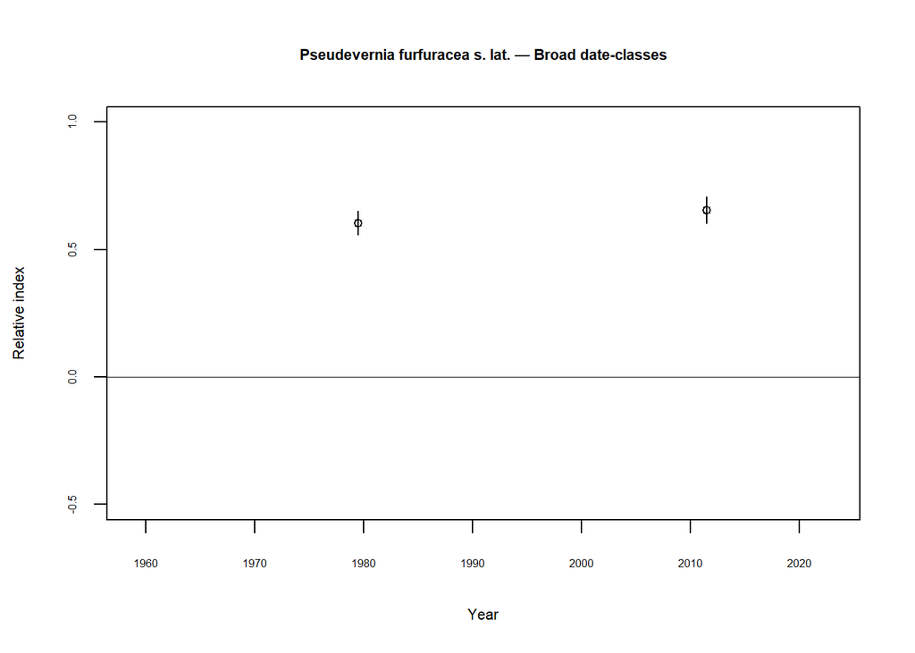

```r
# Read in the Trend file from the relevant frescalo output directory
# Note that these plots could also be made using the `fresOut` or `fresout2` objects above
dat <- read.csv(file = here("outputs/britainEg_atlasDCs_2023-05-22/frescalo_230522/Output/Trend.csv"))
sppToPlot <- dat[dat$Species=="Pseudevernia furfuracea s. lat.",]
plot(1,type='n',
     ylim = c(-0.5,1.0),
xlim = c(1959,2023), xlab = 'Year', ylab ='Relative index',
main = paste0(unique(sppToPlot$Species), " — Broad date-classes"), cex.main = 0.7, cex.lab = 0.7, cex.axis = 0.5)
abline(h = 0, col = "grey5", lty = 1, lwd = 0.7)
points(x = sppToPlot$Time, y = sppToPlot$TFactor, pch = 21, col = "black", cex = 0.8, bg = "white")
arrows(x0 = sppToPlot$Time, x1 = sppToPlot$Time, y0 = sppToPlot$TFactor - sppToPlot$StDev,
       y1 = sppToPlot$TFactor + sppToPlot$StDev, length = 0, col = "black")
```

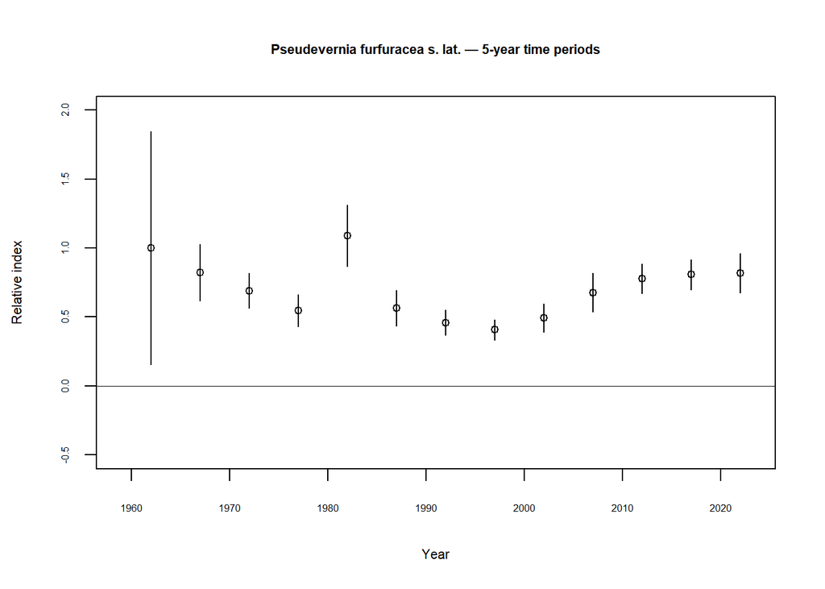

```r
# Same, but analysis using 5 year periods
dat <- read.csv(file = here("outputs/britainEg_quinquen_2023-05-22/frescalo_230522/Output/Trend.csv"))
sppToPlot <- dat[dat$Species=="Pseudevernia furfuracea s. lat.",]
plot(1,type='n',
     ylim = c(-0.5,2.0),
xlim = c(1959,2023), xlab = 'Year', ylab ='Relative index',
main = paste0(unique(sppToPlot$Species), " — 5-year time periods"), cex.main = 0.7, cex.lab = 0.7, cex.axis = 0.5)
abline(h = 0, col = "grey5", lty = 1, lwd = 0.7)
points(x = sppToPlot$Time, y = sppToPlot$TFactor, pch = 21, col = "black", cex = 0.8, bg = "white")
arrows(x0 = sppToPlot$Time, x1 = sppToPlot$Time, y0 = sppToPlot$TFactor - sppToPlot$StDev,
       y1 = sppToPlot$TFactor + sppToPlot$StDev, length = 0, col = "black")
```